# Analysis of General Mills

## 7.2 How much of that revenue is reponsible by promotion or/and ads?

By promo:

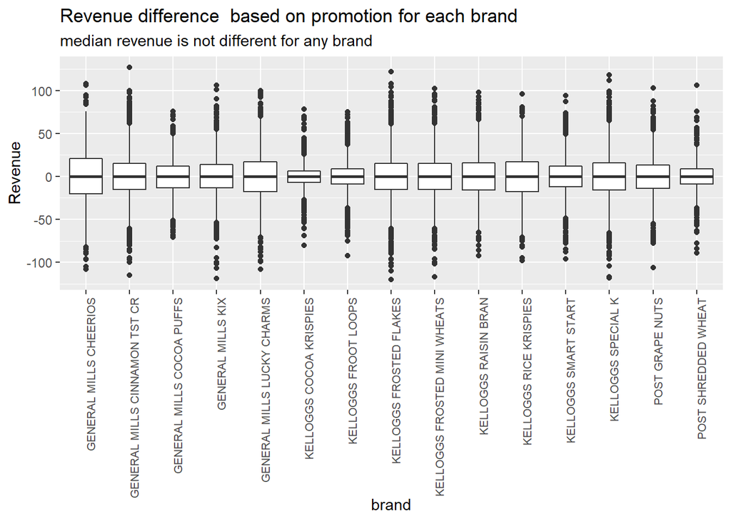

```r
df1<-df %>%
      group_by(promo)%>%
      mutate(rev_diff = c(0,diff(revenue)))

r_diff<-ggplot(df1, mapping=aes(x=brand,y=rev_diff)) +
    geom_boxplot() +
  theme(
       axis.text.x = element_text(angle=90, hjust=1,size = 8))+
  labs(title = "Revenue difference  based on promotion for each brand",subtitle = "median revenue is not different for any brand",y="Revenue")
ggsave(filename = "rev_diff.png", plot = r_diff)
r_diff
```

Comment: There is no significant difference in revenue for each of the brands by using or not using promos. By ads:

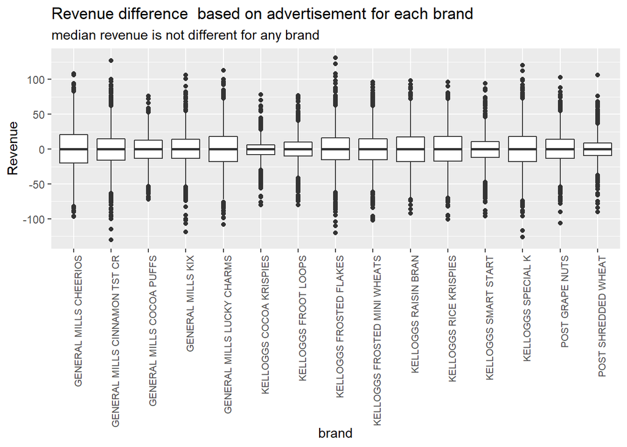

```r
df2<-df %>%
      group_by(ad)%>%
      mutate(rev_diff = c(0,diff(revenue)))

r_diff_ad<-ggplot(df2, mapping=aes(x=brand,y=rev_diff)) +
    geom_boxplot() +
  theme(
       axis.text.x = element_text(angle=90, hjust=1,size = 8))+
  labs(title = "Revenue difference  based on advertisement for each brand",subtitle = "median revenue is not different for any brand",y="Revenue")
ggsave(filename = "rev_diff_ad.png", plot = r_diff_ad)
r_diff_ad
```

Comment:There is not significant difference in revenue for each of the brands among using ad A,ad B and no ad.

# 8 Statistical significance

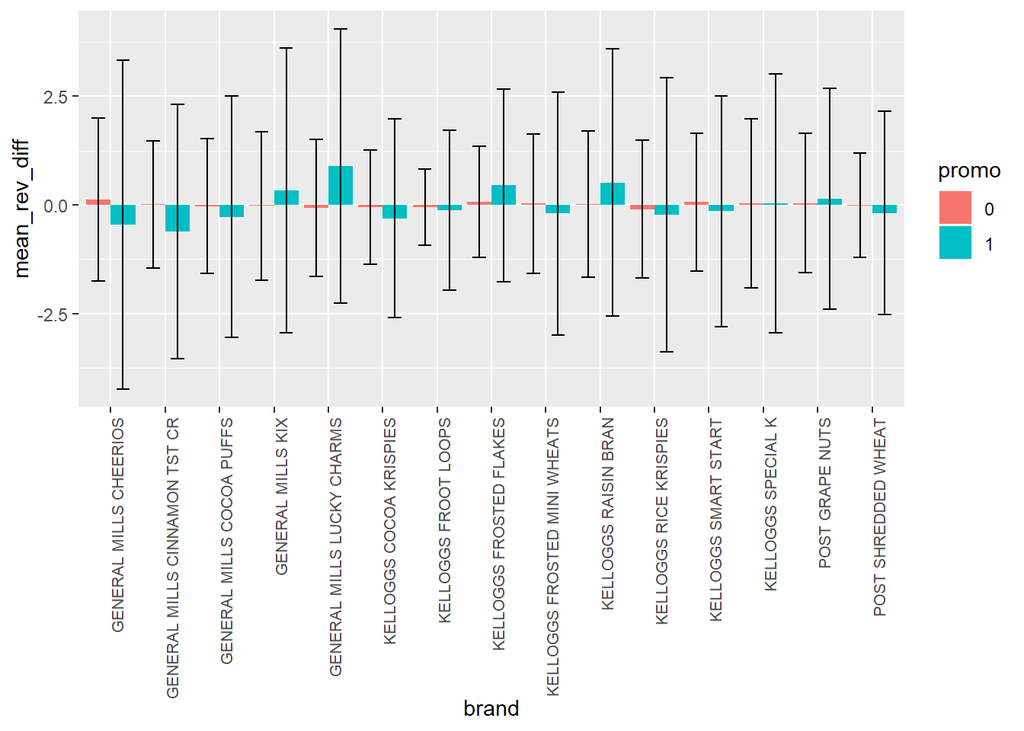

```r
 # 95% CI, get z-value for upper tail, use 0.975 since is one sided
 z <- qnorm(0.975)

 # Incorporate CI into bar graph of means
df1 %>%
     group_by(brand,promo) %>%
     summarise(mean_rev_diff = mean(rev_diff), sd = sd(rev_diff),
               n = n(), ci = z * sd/sqrt(n)) %>%
     ggplot(aes(x = brand, y = mean_rev_diff,fill=promo)) +
     geom_bar(stat = "identity", position = "dodge") +
     theme(
       axis.text.x = element_text(angle=90, hjust=1,size = 8))+
     geom_errorbar(aes(ymin = mean_rev_diff - ci, ymax = mean_rev_diff + ci),
                   width = 0.5, position = position_dodge(0.9))
```

Comment: having promo is not reliable in determining sales

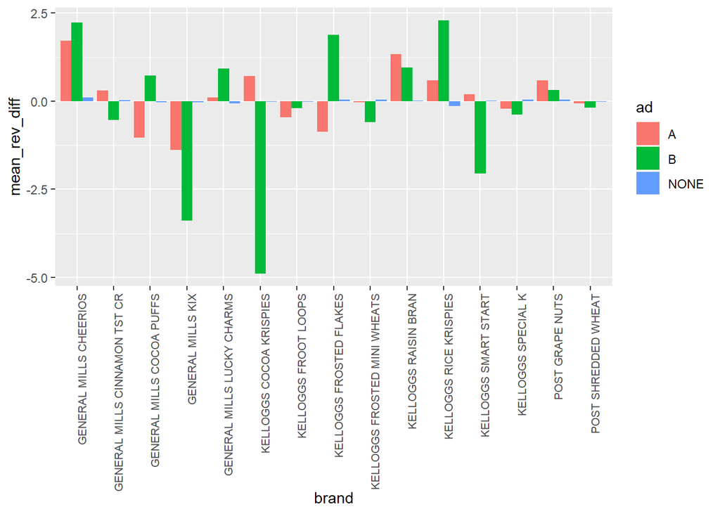

```r
 # 95% CI, get z-value for upper tail, use 0.975 since is one sided
 z <- qnorm(0.975)

 # Incorporate CI into bar graph of means
df2 %>%
     group_by(brand,ad) %>%
     summarise(mean_rev_diff = mean(rev_diff), sd = sd(rev_diff),
               n = n(), ci = z * sd/sqrt(n)) %>%
     ggplot(aes(x = brand, y = mean_rev_diff,fill=ad)) +
     geom_bar(stat = "identity", position = "dodge") +
     theme(
       axis.text.x = element_text(angle=90, hjust=1,size = 8))
```

Comment:

having any ads or no ads is not reliable in determining sales

ad A and B compete in revenue difference only when it is kelloggs raisin bran or general mills cheerios

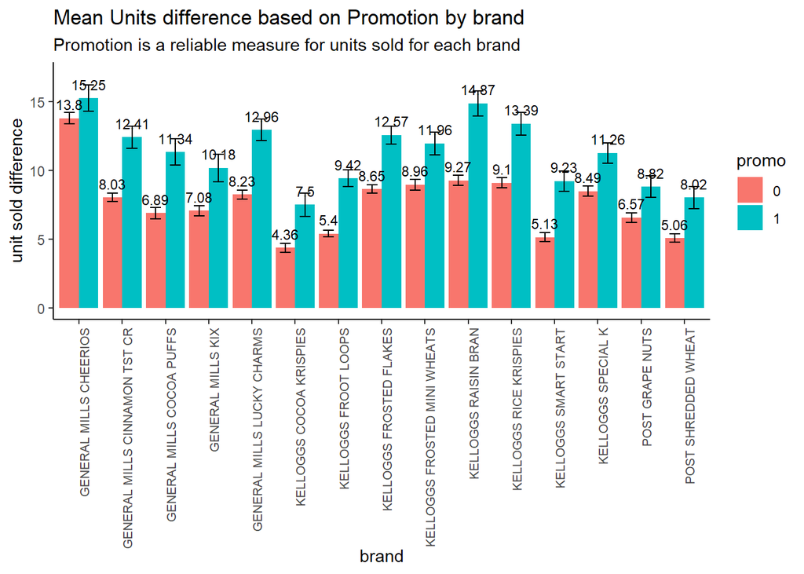

```r
 # 95% CI, get z-value for upper tail, use 0.975 since is one sided
 z <- qnorm(0.975)

 # Incorporate CI into bar graph of means
sig_unit_promo<-df %>%
     group_by(brand,promo) %>%
     summarise(mean_unit_diff = mean(units), sd = sd(units),
               n = n(), ci = z * sd/sqrt(n)) %>%
     ggplot(aes(x = brand, y = mean_unit_diff,fill=promo)) +
     geom_bar(stat = "identity", position = "dodge") +
  geom_text(aes(label = round(mean_unit_diff, 2)), vjust = -.8, color = "black", # vjust moves lables above CI
            position = position_dodge(0.9), size = 3)+
     geom_errorbar(aes(ymin = mean_unit_diff - ci, ymax = mean_unit_diff + ci),
                   width = 0.5, position = position_dodge(0.9)) +
  expand_limits(y=c(0, 17))+
  theme_classic()+
   theme(
       axis.text.x = element_text(angle=90, hjust=1,size = 8))+
   labs(title = "Mean Units difference based on Promotion by brand",
       subtitle = "Promotion is a reliable measure for units sold for each brand",
       x = "brand",
       y = "unit sold difference")
sig_unit_promo
```

```r
ggsave(filename = "sig_unit_promo.png", plot = sig_unit_promo)
```

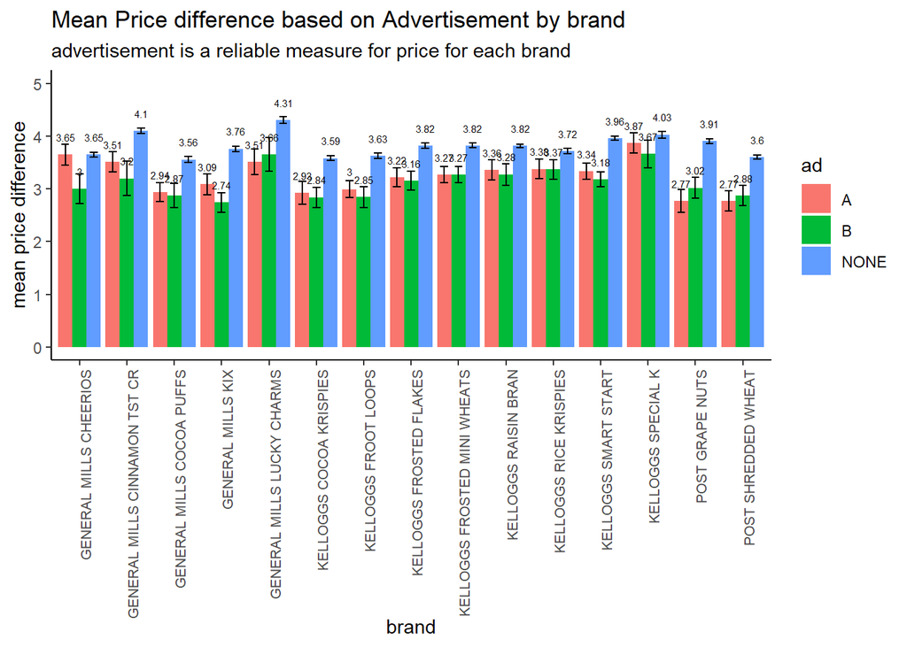

```r
 # 95% CI, get z-value for upper tail, use 0.975 since is one sided
 z <- qnorm(0.975)

 # Incorporate CI into bar graph of means
sig_price_ad<-df %>%
     group_by(brand,ad) %>%
     summarise(mean_price_diff = mean(price), sd = sd(price),
               n = n(), ci = z * sd/sqrt(n)) %>%
     ggplot(aes(x = brand, y = mean_price_diff,fill=ad)) +
     geom_bar(stat = "identity", position = "dodge") +
  geom_text(aes(label = round(mean_price_diff, 2)), vjust = -1.7, color = "black", # vjust moves lables above CI
            position = position_dodge(0.9), size = 2)+
     geom_errorbar(aes(ymin = mean_price_diff - ci, ymax = mean_price_diff + ci),
                   width = 0.5, position = position_dodge(0.9)) +
  expand_limits(y=c(0, 5))+
  theme_classic()+
  theme(
       axis.text.x = element_text(angle=90, hjust=1,size = 8))+
  labs(title = "Mean Price difference based on Advertisement by brand",
       subtitle = "advertisement is a reliable measure for price for each brand",
       x = "brand",
       y = "mean price difference")
sig_price_ad
```

```r
ggsave(filename = "sig_price_ad.png", plot = sig_price_ad)
```

Comment: mean price difference are reliable across the brands with ads taken into account

```r
mod <- glm(rev_diff ~ brand+promo+ad+package+volume,
           data = df1)
summary(mod)
```

```
##
## Call:
## glm(formula = rev_diff ~ brand + promo + ad + package + volume,
##     data = df1)
##
## Deviance Residuals:
##      Min        1Q    Median        3Q       Max
## -120.449   -14.642     0.149    14.035   126.876
##
## Coefficients:
##                                      Estimate Std. Error t value Pr(>|t|)
## (Intercept)                        -6.714e-01  1.136e+00  -0.591   0.5544
## brandGENERAL MILLS CINNAMON TST CR -2.233e-01  9.389e-01  -0.238   0.8120
## brandGENERAL MILLS COCOA PUFFS     -1.536e-01  1.078e+00  -0.143   0.8867
## brandGENERAL MILLS KIX              8.814e-06  1.031e+00   0.000   1.0000
## brandGENERAL MILLS LUCKY CHARMS    -1.126e-02  9.498e-01  -0.012   0.9905
## brandKELLOGGS COCOA KRISPIES       -1.274e-01  1.128e+00  -0.113   0.9101
## brandKELLOGGS FROOT LOOPS          -1.232e-01  8.918e-01  -0.138   0.8901
## brandKELLOGGS FROSTED FLAKES       -6.498e-02  9.131e-01  -0.071   0.9433
## brandKELLOGGS FROSTED MINI WHEATS  -2.539e-01  9.912e-01  -0.256   0.7978
## brandKELLOGGS RAISIN BRAN          -2.155e-01  1.082e+00  -0.199   0.8422
## brandKELLOGGS RICE KRISPIES        -2.133e-01  9.784e-01  -0.218   0.8275
## brandKELLOGGS SMART START          -1.696e-01  1.053e+00  -0.161   0.8721
## brandKELLOGGS SPECIAL K            -4.998e-02  9.914e-01  -0.050   0.9598
## brandPOST GRAPE NUTS               -2.915e-01  1.093e+00  -0.267   0.7896
## brandPOST SHREDDED WHEAT           -2.115e-01  1.039e+00  -0.204   0.8387
## promo1                             -1.420e-01  4.663e-01  -0.304   0.7608
## adB                                 2.058e+00  1.066e+00   1.931   0.0535
## adNONE                              3.382e-01  7.387e-01   0.458   0.6471
## packageCUP                         -2.831e-03  1.306e+00  -0.002   0.9983
## volume                              4.365e-01  6.615e-01   0.660   0.5094
##
## (Intercept)
## brandGENERAL MILLS CINNAMON TST CR
## brandGENERAL MILLS COCOA PUFFS
## brandGENERAL MILLS KIX
## brandGENERAL MILLS LUCKY CHARMS
## brandKELLOGGS COCOA KRISPIES
## brandKELLOGGS FROOT LOOPS
## brandKELLOGGS FROSTED FLAKES
## brandKELLOGGS FROSTED MINI WHEATS
## brandKELLOGGS RAISIN BRAN
## brandKELLOGGS RICE KRISPIES
## brandKELLOGGS SMART START
## brandKELLOGGS SPECIAL K
## brandPOST GRAPE NUTS
## brandPOST SHREDDED WHEAT
## promo1
## adB                                .
## adNONE
## packageCUP
## volume
## ---
## Signif. codes:  0 '***' 0.001 '**' 0.01 '*' 0.05 '.' 0.1 ' ' 1
##
## (Dispersion parameter for gaussian family taken to be 694.8016)
##
##     Null deviance: 15171166  on 21849  degrees of freedom
## Residual deviance: 15167518  on 21830  degrees of freedom
## AIC: 205008
##
## Number of Fisher Scoring iterations: 2
```

Comment:

Our summary here shows that since the p value is very large for promo1, we can say that the coefficient of having promotion is statistically insignificant at 95% confidence interval with respect to not having promotion keeping other factors constant.

Our summary here shows that since the p value is very large for adNone, we can say that the coefficient of having no ads is statistically insignificant at 95% confidence interval with respect to having ad A keeping other factors constant.

Our summary here shows that since the p value is larger than 0.05 for adB, we can say that the coefficient of having ad b is statistically insignificant at 95% confidence interval with respect to having ad A keeping other factors constant.

```r
mod1 <- glm(price ~ brand+promo+ad+package+volume,
           data = df1)
summary(mod1)
```

```
##
## Call:
## glm(formula = price ~ brand + promo + ad + package + volume,
##     data = df1)
##
## Deviance Residuals:
##     Min       1Q   Median       3Q      Max
## -2.9452  -0.4142  -0.0443   0.4117   6.0602
##
## Coefficients:
##                                     Estimate Std. Error t value Pr(>|t|)
## (Intercept)                         2.235618   0.027160  82.314  < 2e-16
## brandGENERAL MILLS CINNAMON TST CR  0.021795   0.022453   0.971   0.3317
## brandGENERAL MILLS COCOA PUFFS     -0.136537   0.025770  -5.298 1.18e-07
## brandGENERAL MILLS KIX              0.114476   0.024649   4.644 3.43e-06
## brandGENERAL MILLS LUCKY CHARMS     0.371259   0.022714  16.345  < 2e-16
## brandKELLOGGS COCOA KRISPIES        0.080672   0.026987   2.989   0.0028
## brandKELLOGGS FROOT LOOPS           0.002528   0.021327   0.119   0.9056
## brandKELLOGGS FROSTED FLAKES       -0.321631   0.021836 -14.729  < 2e-16
## brandKELLOGGS FROSTED MINI WHEATS  -0.472586   0.023704 -19.937  < 2e-16
## brandKELLOGGS RAISIN BRAN          -0.880740   0.025875 -34.039  < 2e-16
## brandKELLOGGS RICE KRISPIES         0.031118   0.023398   1.330   0.1836
## brandKELLOGGS SMART START          -0.037521   0.025194  -1.489   0.1364
## brandKELLOGGS SPECIAL K             0.407257   0.023709  17.177  < 2e-16
## brandPOST GRAPE NUTS               -0.879209   0.026135 -33.641  < 2e-16
## brandPOST SHREDDED WHEAT           -0.440622   0.024841 -17.738  < 2e-16
## promo1                             -0.858783   0.011151 -77.011  < 2e-16
## adB                                 0.014909   0.025487   0.585   0.5586
## adNONE                              0.225012   0.017666  12.737  < 2e-16
## packageCUP                         -1.310767   0.031244 -41.953  < 2e-16
## volume                              1.648435   0.015819 104.206  < 2e-16
##
## (Intercept)                        ***
## brandGENERAL MILLS CINNAMON TST CR
## brandGENERAL MILLS COCOA PUFFS     ***
## brandGENERAL MILLS KIX             ***
## brandGENERAL MILLS LUCKY CHARMS    ***
## brandKELLOGGS COCOA KRISPIES       **
## brandKELLOGGS FROOT LOOPS
## brandKELLOGGS FROSTED FLAKES       ***
## brandKELLOGGS FROSTED MINI WHEATS  ***
## brandKELLOGGS RAISIN BRAN          ***
## brandKELLOGGS RICE KRISPIES
## brandKELLOGGS SMART START
## brandKELLOGGS SPECIAL K            ***
## brandPOST GRAPE NUTS               ***
## brandPOST SHREDDED WHEAT           ***
## promo1                             ***
## adB
## adNONE                             ***
## packageCUP                         ***
## volume                             ***
## ---
## Signif. codes:  0 '***' 0.001 '**' 0.01 '*' 0.05 '.' 0.1 ' ' 1
##
## (Dispersion parameter for gaussian family taken to be 0.3973636)
##
##     Null deviance: 21723.1  on 21849  degrees of freedom
## Residual deviance:  8674.4  on 21830  degrees of freedom
## AIC: 41864
##
## Number of Fisher Scoring iterations: 2
```

Comment:

Our summary here shows that since the p value is small for promo1, we can say that the coefficient of having promotion is statistically significant at 95% confidence interval with respect to not having promotion keeping other factors constant.

Our summary here shows that since the p value is small for adNone, we can say that the coefficient of having no ads is statistically significant at 95% confidence interval with respect to having ad A keeping other factors constant.

# 9 Summary

General Mills earns the highest revenue compared to its competitior because of the following crucial findings:

In the first two quarters, 26 weeks, general advertises for coca puffs where kellogs did not

General Mills did not advertise for the same regular flavour of Kix when they knew that keloogss already dominates with frosted flakes

General Mills is the only one who produced cinnamon flavour. So, they promote cinnamon toast the most throughout the 52 weeks. Most of General Mills sales come from cinnamon toast and most of ther evenue comes from cinnamon toast

Lucky charm of General Mills dominate in advertisement making in more popular than Kellogg’s smart tart and kellogg’s K